# Timer

# Timer triggers events over time

The `Timer` node is a countdown timer that can run once or cycle.

You specify how long the timer should last. It emits a signal when it times out, allowing us to trigger what should happen next.

In this guide, you will learn:

- How to set up a timer and use its essential methods and signals.
- How to use a one-shot timer to create an ability cooldown.
- How to create a cyclic timer to trigger events repeatedly.
- How to create a timer dynamically in code and wait for it to finish.

Contents:

- Setting up a Timer
- Timer’s key features
  - Starting a timer of a given duration
  - Starting the timer automatically
  - Triggering events when your timer finishes
- How to use a Timer in practice
  - Creating a cooldown for an ability
  - Spawning enemies periodically
  - Delaying the execution of code
- Your questions
  - How can I check how long a timer has left?
  - What is the timer’s process mode?

## Setting up a Timer

There are five steps to using a `Timer` node:

1. Add a `Timer` node to your scene.
2. Set the timer’s *Wait Time*.
3. If you want it only to play once, turn on its *One Shot* property. By default, the `Timer` node cycles.
4. Start the timer in code with `start()` or turn on its *Autostart* property.
5. Connect the `timeout` signal to a function or call the `is_stopped()` method to trigger events in your code.

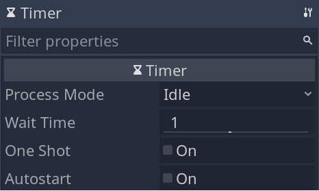

## Timer’s key features

### Starting a timer of a given duration

A `Timer` uses its `wait_time` property to determine how long it should count down.

When the timer finishes counting down, it emits the `timeout` signal.

To change the timer’s `wait_time` in code, you should use a parameter when calling the timer’s `start()` function. `Timer.start()` starts the countdown and takes an optional parameter that resets the node’s `wait_time`.

```
# Count down for a random time between one and two seconds.
$Timer.start(rand_range(1.0, 2.0))
```

**Note:** To make the duration truly random, you will need to use the `randomize()` function to generate and use a new random seed, before calling `rand_range()`.

### Starting the timer automatically

Before adding your `Timer` to the scene tree, you can turn on its *Autostart* property to have it start automatically.

### Triggering events when your timer finishes

Timers emit the `timeout` signal when they finish. You can connect this signal to your script to run code in response.

Alternatively, if the timer’s `one_shot` property is `true`, you can check if the timer is still running or not by calling the `is_stopped()` function.

## How to use a Timer in practice

You’ll get to use timers often. Here are three cases in which you can use them:

1. Creating a cooldown for an ability or a weapon.
2. Spawning enemies periodically.
3. Delaying the execution of code.

### Creating a cooldown for an ability

You can use timers for anything that requires a cooldown. Examples include the fire rate on a weapon, or a special ability that requires that the player wait before using it again.

Here’s how to set it up.

Add a `Timer` node to your scene. In the *Inspector*, turn *One Shot* on and set the *Wait Time* to how long you want your cooldown to last.

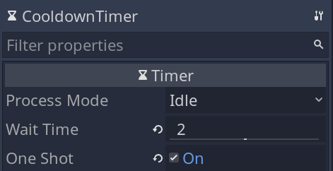

In your script, create a function for the ability you want to have a cooldown.

At the start of this function, you can check whether the ability has cooled down using the `Timer`’s `is_stopped()` function:

- If the timer isn’t stopped, our ability is still cooling down so we shouldn’t do anything.
- If the timer is stopped, our ability has cooled down, so we can start the timer and activate our ability.

Here’s how we used it to code a dash mechanic:

```
## Makes the ship dash for a few moments.
func boost() -> void:
    if not $Timer.is_stopped():
        return
    # This line starts the cooldown.
    $Timer.start()

    #...
    # Increase the player's speed to simulate a dashing effect.
    # This tween instantly increases the player's speed and animates it going
    # back down.
    $Tween.interpolate_property(
        $Player,
        "speed",
        player_base_speed * boost_rate,
        player_base_speed,
        0.5,
        Tween.TRANS_EXPO,
        Tween.EASE_IN
    )
    # We also scale the player up to emphasize the boost visually.
    $Tween.interpolate_property($Player, "scale", Vector2.ONE * 1.5, Vector2.ONE, 0.5)
    $Tween.start()
```

### Spawning enemies periodically

You can use cyclic timers for events that repeat, like spawning enemies at regular time intervals.

[figure not shown]

To do so, start with a `Timer` node in your scene.

In the *Inspector*, ensure *One Shot* is turned off and turn on *Autostart*. This will make the timer start automatically and emit the `timeout` signal every *Wait Time* interval.

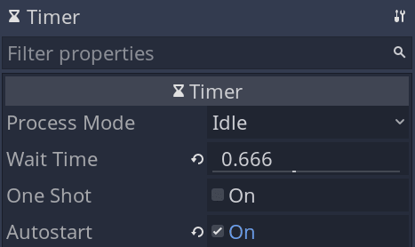

Then, connect the timer’s `timeout` signal to a script. The timer will emit it every time it times out, calling a function at regular intervals.

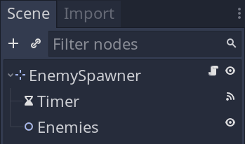

```
export var max_spawn_count := 9
export var enemy_scene: PackedScene

var _player_reference: Player

onready var _enemy_container := $Enemies

#...

func spawn_enemy() -> void:
    # Check we haven't already spawned more than 9 enemies and check
    # that the player node exists.
    if _enemy_container.get_child_count() >= max_spawn_count or not _player_reference:
        return

    # Instance a new enemy node and add it as a child of the spawner.
    var enemy = enemy_scene.instance()
    _enemy_container.add_child(enemy)
    enemy.player_reference = _player_reference


func _on_Timer_timeout() -> void:
    spawn_enemy()
```

### Delaying the execution of code

Godot’s `SceneTree` object has a method to create a one-shot timer in a single line of code: `create_timer()`.

Combined with the `yield()` keyword, it helps you delay the execution of some code and sequence time-sensitive events in GDScript.

```
# Creates a one-second timer and pauses execution until it times out.
yield(get_tree().create_timer(1.0), "timeout")
```

This function does not create a `Timer` node. Instead, it creates a simpler `SceneTreeTimer`, which always starts automatically and cannot cycle.

Like the `Timer` node, though, it exposes a `timeout` signal. It’s a convenient feature that’ll save you from creating many `Timer` nodes.

Here’s how you could use it to wait between short animations in an animation sequence.

```
## A sequence of four animation names to play with our AnimationPlayer.
var light_sequence := [
    "stop",
    "ready",
    "go",
    "stop_soon"
]

onready var _animation_player := $AnimationPlayer


func animate_traffic_lights() -> void:
    # We loop over and play each animation from `light_sequence`.
    for animation in light_sequence:
        _animation_player.play(animation)
        # After each animation, we wait for a random duration between one
        # and two seconds.
        yield(get_tree().create_timer(rand_range(1.0, 2.0)), "timeout")
```

## Your questions

### How can I check how long a timer has left?

Timers have a `time_left` property you can access to check how much time remains until the `Timer` times out.

You can use the property to display the time left to finish a level or a challenge to the player.

### What is the timer’s process mode?

`Timer` nodes have a choice of two process modes: *Idle* and *Physics*.

The *Physics* mode matches the `_physics_process()` callback of nodes, while the *Idle* mode makes the timer update in sync with other nodes’ `_process()` functions.

Usually, *Idle* processing will be what you want. However, if your `Timer` interacts with physics objects like a `RigidBody`, it’s worth considering using *Physics* mode.